# ENZOEM Módulo 2 - Test estadísticos en ciencias experimentales

[figure not shown]

# **Presentación**

En este espacio se encuentran los contenidos para el Módulo 2 - Test estadísticos en ciencias experimentales del Curso de Estadística ENZOEM, que tiene la siguiente estructura:

1. Generalidades. [Materiales prácticos](https://jabiologo.github.io/web/tutorials/enzoem_2_files/enzoem2_1.zip) y [presentaciones](https://jabiologo.github.io/web/tutorials/enzoem_2_files/modulo2_1_compressed.pdf)
2. Principales test paramétricos y no paramétricos. [Materiales prácticos](https://jabiologo.github.io/web/tutorials/enzoem_2_files/enzoem2_2.zip) y [presentaciones](https://jabiologo.github.io/web/tutorials/enzoem_2_files/modulo2_1_2_compressed.pdf).
3. El modelo lineal general (GLM) y diseños avanzados. [Presentaciones sobre diseños experimentales](https://jabiologo.github.io/web/tutorials/enzoem_2_files/enzoem3.pdf), [materiales prácticos](https://jabiologo.github.io/web/tutorials/enzoem_2_files/enzoem2_3.zip).

# **1. Generalidades**

### Conceptos básicos

La estadística es una ciencia que nos permite cuantificar la realidad y analizarla con el fin de obtener explicaciones o predicciones.

- **Población estadística:** Es el conjunto completo de todos los elementos y sobre los cuales queremos obtener conclusiones (inferencia).
- **Muestra:** Es una parte representativa de la población estadística.
- **Unidad muestral:** Es cada elemento individual de la población o muestra sobre el cual se realiza una observación o medición. Es la entidad básica que se estudia.
- **Variable:** Es una característica o cualidad que puede variar entre los diferentes elementos de una población o muestra. Las variables son lo que medimos, observamos o registramos.
- **Observación (dato):** Es el valor específico que toma una variable para una unidad particular de la población o muestra. Es un registro individual de una medida o característica.

### Exactitud y precisión

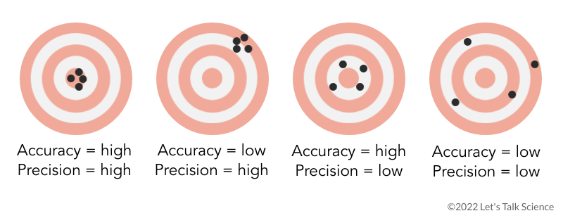

### Tipos de variables

1. Cuantitativas
   - Continuas
   - Discretas
2. Semicuantitativas u ordinales
3. Cualitativas o nominales

### Distribuciones de probabilidad

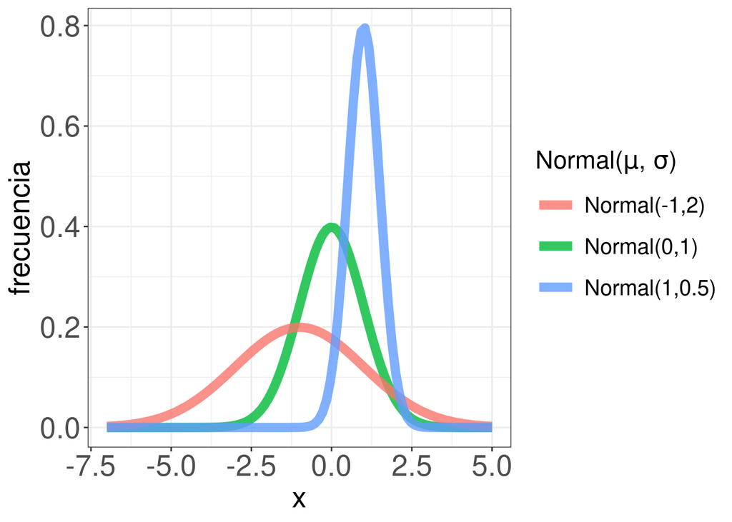

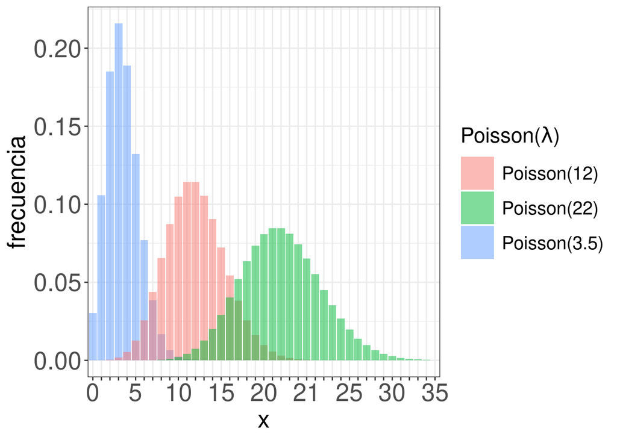

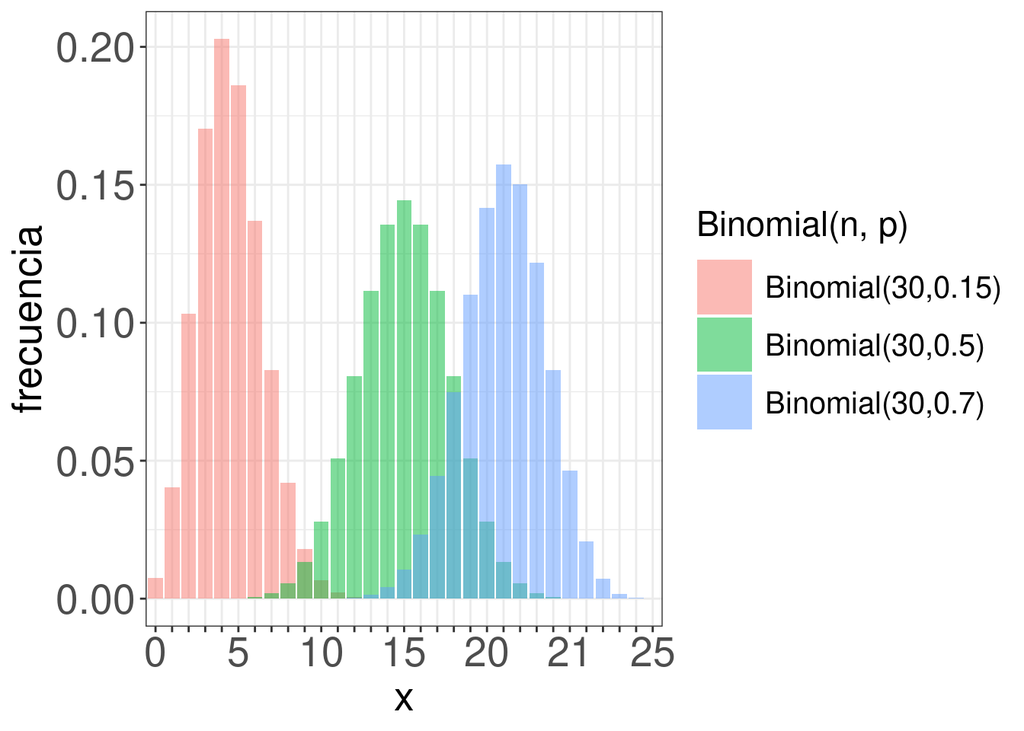

### Estadística descriptiva

- **Media** ($\mu$): promedio de un conjunto de datos.
- **Mediana**: valor central de un conjunto de datos cuando estos están ordenados de menor a mayor. Cuantiles: cuartiles, deciles.
- **Moda**: valor más frecuente dentro de la muestra.
- **Desviación estándar, varianza** ($\sigma$, $\sigma^2$): mide la dispersión o variabilidad de los datos alrededor de la media.

### Contraste de hipótesis

El contraste de hipótesis es un procedimiento estadístico que se utiliza para tomar decisiones sobre una **afirmación o suposición (hipótesis)** acerca de una **población**, basándose en la evidencia de una **muestra** de datos.

- **Hipótesis nula ($H_0$):** Afirmación inicial que asumimos como verdadera. No hay efecto, no hay diferencia o no hay relación entre las variables en la población.
- **Hipótesis alternativa ($H_1$):** Sugiere que sí hay un efecto, una diferencia o una relación entre las variables de la población.
- **P-valor:** una medida de la fuerza de la evidencia en contra de la hipótesis nula. Un P-valor pequeño (generalmente menor a 0.05) indica que el resultado observado es poco probable bajo la hipótesis nula, lo que nos lleva a rechazarla

### Errores y valores anómalos

- **Errores:** fallos no intencionados durante el proceso de recolección, medición o registro de los datos. Pueden deberse a equivocaciones humanas, mal funcionamiento de instrumentos, o fallos en la transcripción.
- **Valores anómalos:** observaciones individuales en un conjunto de datos que se desvían significativamente de la mayoría de los demás valores. Pueden ser el resultado de errores en los datos o representar fenómenos inusuales pero genuinos.

### Transformaciones: estandarización y logaritmo

- **Estandarización:** transformar nuestra variable para que su media sea cero y su desviación estándar sea uno.

$\frac{(x_i - \bar{x})}{\sigma}$

- **Logaritmo:** comprimir valores grandes, estirar valores pequeños
1. Linealizar relaciones no lineales.
2. Estabilizar la varianza (homocedasticidad).
3. Reducir la asimetría (lo que a menudo lleva a una distribución normal).
4. Reflejar la naturaleza multiplicativa o proporcional de muchos fenómenos del mundo real.

# **2. Principales test paramétricos y no paramétricos**

# **3. El modelo lineal general (GLM)**

# **4. Diseños avanzados: GLS y GLMM**